```python
import numpy as np
import pandas as pd
import matplotlib.pyplot as plt
import seaborn as sns
%matplotlib inline

df = pd.read_csv('ProcessedTweets-.csv')
df['date'] = pd.to_datetime(df.date)
df = df.query("week_num != 16")
```

# Project Introduction

**Project Outline**

- CSULB J104 - Student Twitter Engagement
  - CSULB - J104 - Social Media Communication
  - Professor Kehoe
  - Assignment - *Students tweet twice per week, and must include #CSULB104*
- Phase 1 - Research Scope
  - Scrape Tweets including #CSULB104
  - Examine student/tweet sentiment, tweet frequency, and patterns in time posted or the subject of the week
- Role - Principle Researcher/Data Scientist

**Project Goals**

- **Objective - Analyze J104 tweets to establish baseline understanding of student tweet behavior and sentiment**
- Research Tools -
  - Twitter Scraping - Twython
  - Data Processing - pandas/numpy
  - Visualization - seaborn
  - Sentiment Analysis - vaderSentiment
- Areas of Interest -
  - User/Tweet Sentiment - positivity or negativity of a tweet, or a user's general positive or negative sentiment throughout the course. Sentiment scores fall between 1 (Completely Positive) and -1 (Completely Negative), while neutral scores are between .05 and -.05.
  - Tweet Frequency - the number of times a user posts
  - Course Topics - weeks of study during the course, and the specific subjects students were tweeting about
  - Day/Time tweeted - time/day hour a tweet was posted

**Data Collection Period**

```python
# Dates collected - start and end dates
print('\t-- Dates Collected -- ')
print('Date Started - ', df.date.min())
print('Date Finished - ', df.date.max())
```

```
	-- Dates Collected --
Date Started -  2018-09-01 00:24:40
Date Finished -  2018-12-12 03:50:21
```

**Total Sample Data**

```python
# Target Sample -
print('\t-- Target Sample-- ')
print('Twitter users with #CSULB140 contained in tweets')

# Totals -
print('\n\tTotal Tweets/Users')
print('Tweets Collected - ', df.text.count())
print('Students Included - ', df.user.nunique())
```

```
	-- Target Sample--
Twitter users with #CSULB140 contained in tweets

	Total Tweets/Users
Tweets Collected -  1286
Students Included -  93
```

# Tweet/User - Reporting

**Research Objective - Better understand user and tweet level trends, particularly those related to sentiment**

**Tweet Sentiment Over Time**

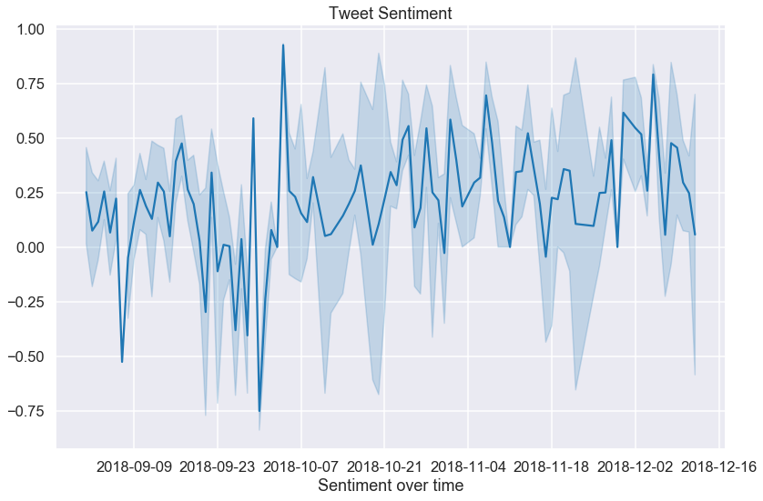

```python
# setting style
sns.axes_style('darkgrid')
sns.set_style('darkgrid')
sns.set_context(context='talk', font_scale=1)
plt.figure(figsize=(12,8))
sns.lineplot(x=df.date.dt.date, y='text_cmp', data=df)

# plot customization
plt.title('Tweet Sentiment')
plt.ylabel('')
plt.xlabel('Sentiment over time')
plt.tight_layout()
```

**Descriptive Statistics - Users**

- Sentiment Coding - (S = sentiment score)
  - Negative - (S <= -.05)
  - Neutral - (-.05 < S < .05)
  - Positive - (.05 <= S)
- Vast majority of students were Positive users, meaning most students generally wrote positive tweets throughout the course (n = 61, 66%)
- Non-Positive users, those who generally wrote either Neutral or Negative tweets, were a comparatively much smaller portion of total sample.
  - Neutral (n = 14, 15%)
  - Negative (n = 18, 19%)
- Most negative users were Extremely Negative (S <= - .5), rather than Slightly Negative (-.5 < S <= -.05).
  - Extremely Negative (n = 11, 61%)
  - Slightly Negative (n = 7, 39%)

```python
# Descriptive Statistics - Users
print('\t User Data')
print('Total Users -', df.user.nunique())
print('\n\t User Averages')
print('Weekly # Users -', df.groupby('week_num').user.nunique().mean())
print('User Sentiment-', df.groupby('user').text_cmp.mean().mean()*100)

# positive/nuetral/negative coding
print('\n\t User Sentiment Totals')
print(df.drop_duplicates(subset=['user']).UserSent_Bucket.value_counts())
```

```
	 User Data
Total Users - 93

	 User Averages
Weekly # Users - 40.733333333333334
User Sentiment- 10.342718244398624

	 User Sentiment Totals
Positive    61
Negative    18
Neutral     14
Name: UserSent_Bucket, dtype: int64
```

**User Sentiment - Bar Graph**

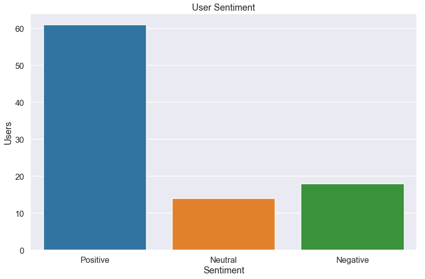

```python
users = df.drop_duplicates(subset=['user'])
plt.figure(figsize=(12,8))
sns.countplot(x='UserSent_Bucket', data=users)
sns.set_context(context='talk', font_scale=1)

# plot customization
plt.title('User Sentiment')
plt.ylabel('Users')
plt.xlabel('Sentiment')
plt.tight_layout()
```

**User Sentiment - Distribution**

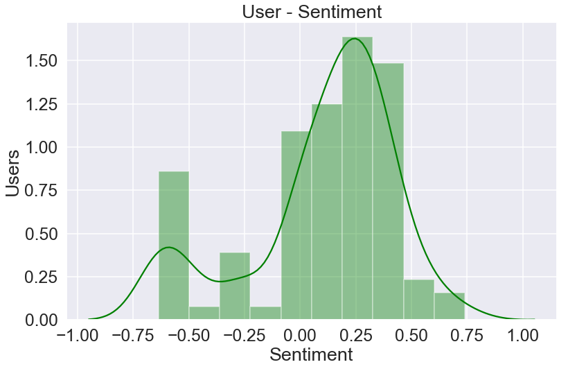

```python
# User - Sentiment Distribution
sns.axes_style('darkgrid')
sns.set_style('darkgrid')
sns.set_context(context='talk', font_scale=1.5)
plt.figure(figsize=(12,8))

users = df.copy()
users.drop_duplicates(subset='user', inplace=True)
users.dropna(subset=['Sentiment_Mean'], inplace=True)

sns.distplot(users.Sentiment_Mean, bins=10, color='g')

# plot customization
plt.title('User - Sentiment')
plt.ylabel('Users')
plt.xlabel('Sentiment')
plt.tight_layout()
```

**Descriptive Statistics - Tweets**